# Lab1

```
          LAB 1
```

Exercise 1.1 INPUT: 60 85 72 59 37 75 93 7 98 63 41 90 5 17 97

```r
x=c(60,85,72,59,37,75,93,7,98,63,41,90,5,17,97)
sx=stem(x)
```

```
##
##   The decimal point is 1 digit(s) to the right of the |
##
##   0 | 577
##   2 | 7
##   4 | 19
##   6 | 0325
##   8 | 50378
```

```r
print(sx)
```

Exercise 1.2 ######################################################### The decimal point is 1 digit(s) to the right of the |

8 | 028 9 | 115578 10 | 1669 11 | 01  
##########################################################

The data from the given stem and leaf plot are: 80,82,88,91,91,95,95,97,98,101,106,106,109,110,111

```r
data=c(80,82,88,91,91,95,95,97,98,101,106,106,109,110,111)
stem(data)
```

```
##
##   The decimal point is 1 digit(s) to the right of the |
##
##    8 | 028
##    9 | 115578
##   10 | 1669
##   11 | 01
```

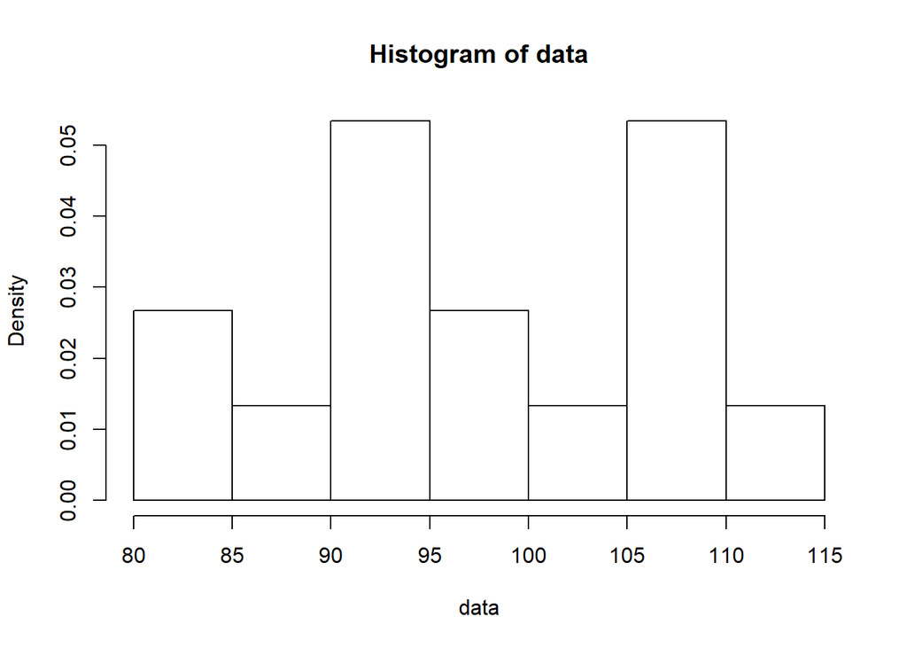

```r
hist(data,probability=TRUE)
```

Exercise 1.3 1st Randomization

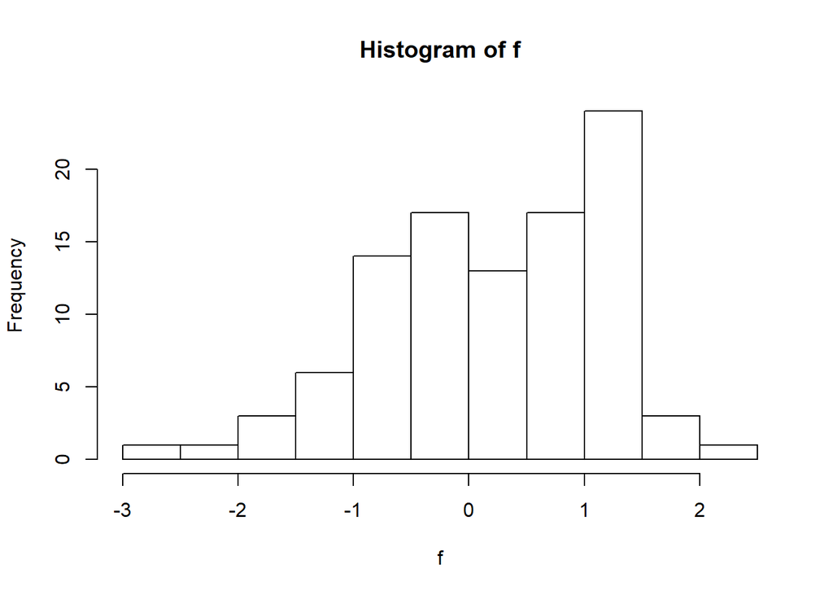

```r
f=rnorm(100)
hist(f)
```

2nd Randomization

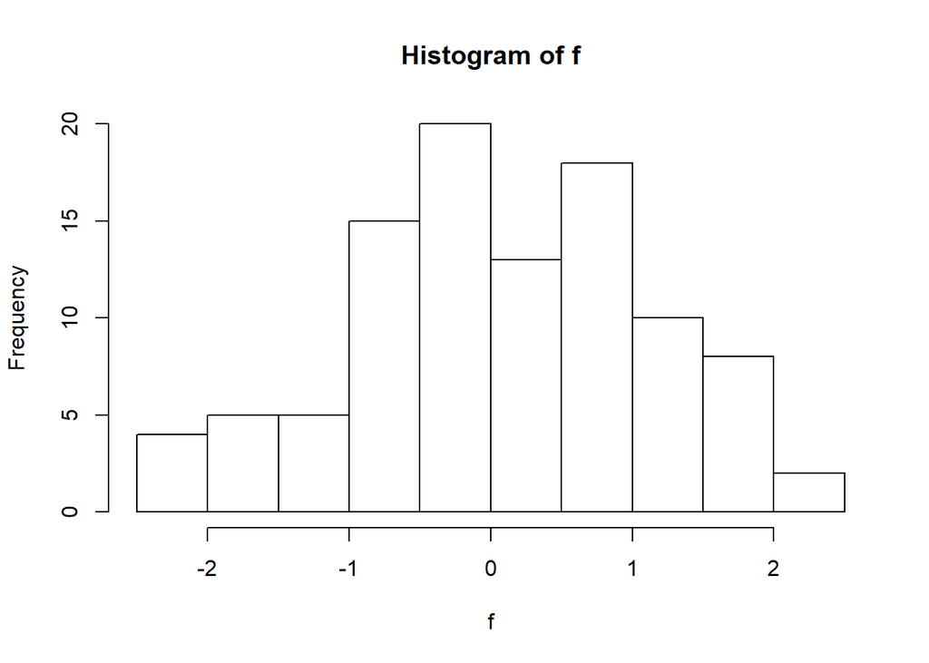

```r
f=rnorm(100)
hist(f)
```

As we see the two histograms are not the same

Exercise 1.4

library(“UsingR”)

```r
library("UsingR")
```

For south dataset:

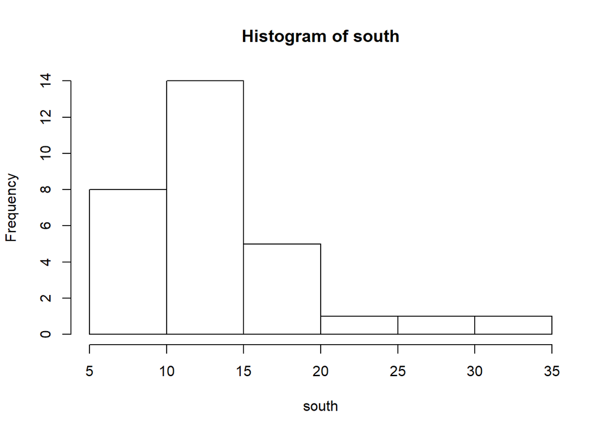

```r
data(south)
hist(south)
```

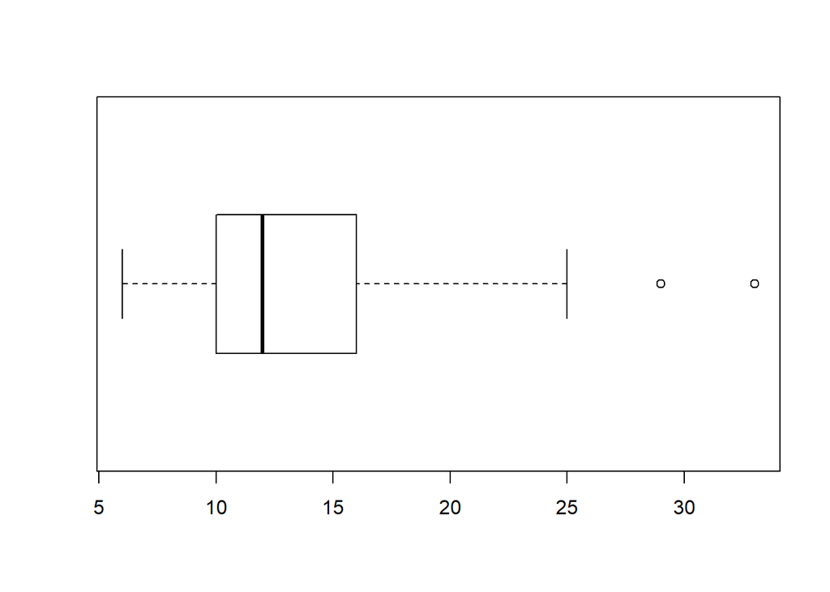

```r
boxplot(south,horizontal = TRUE)
```

For crime:

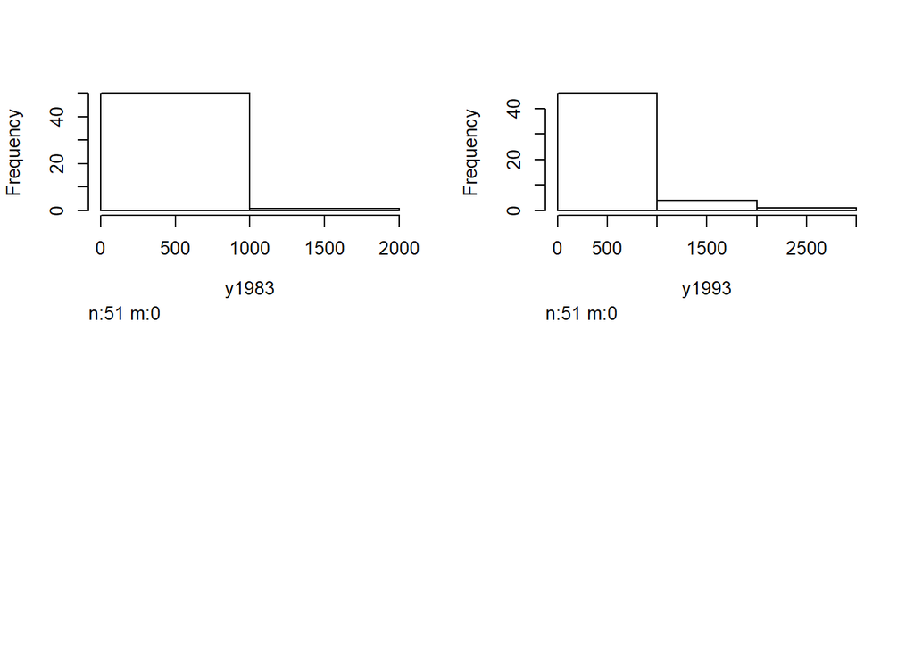

```r
data(crime)
hist(crime)
```

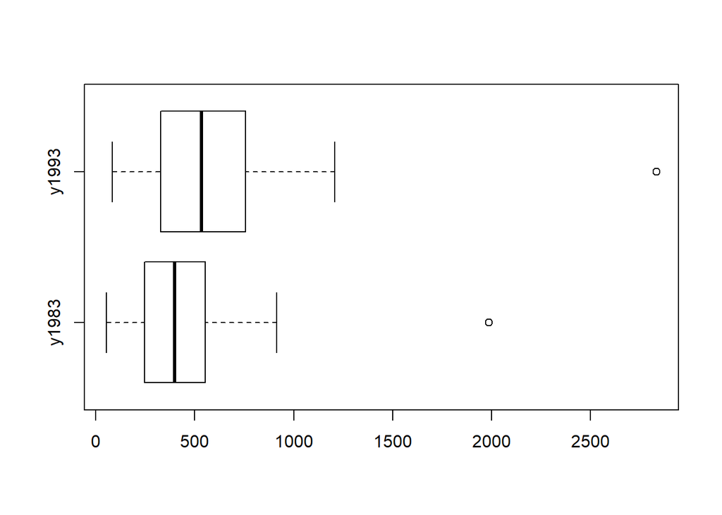

```r
boxplot(crime,horizontal = TRUE)
```

For aid dataset:

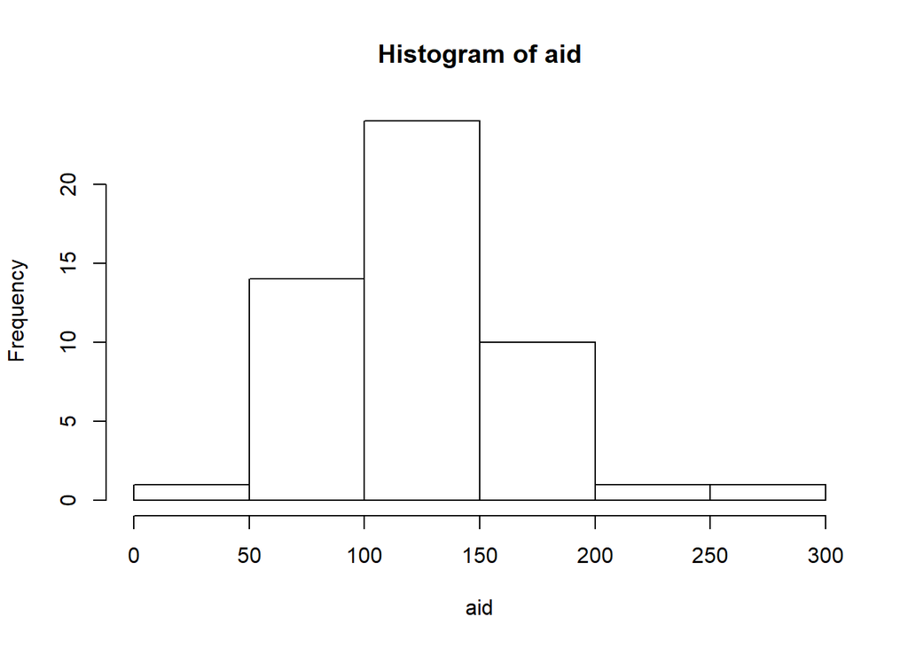

```r
data(aid)
hist(aid)
```

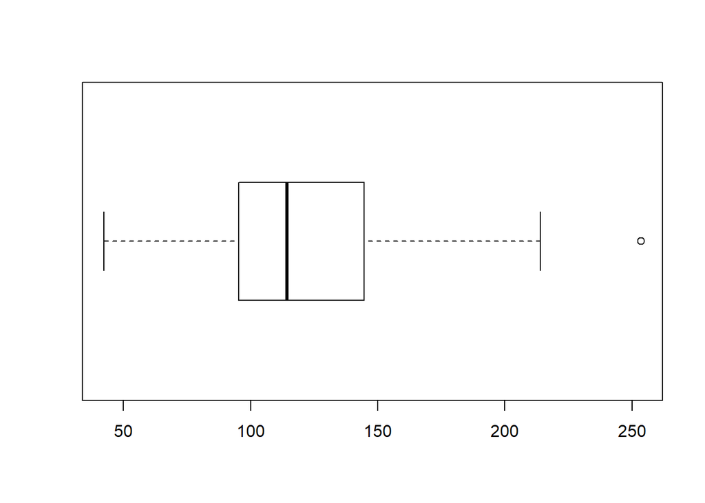

```r
boxplot(aid,horizontal=TRUE)
```

Exercise 1.5

1. Predict for bumpers:

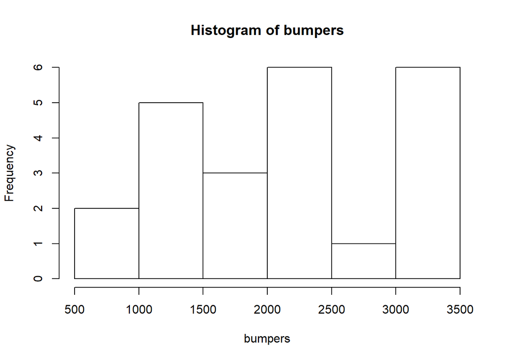

```r
data(bumpers)
hist(bumpers)
```

Predictions: Median:2100 Mean:2000 Standard deviation:500

```r
median(bumpers)
```

```
## [1] 2129
```

```r
mean(bumpers)
```

```
## [1] 2122.478
```

```r
sd(bumpers)
```

```
## [1] 798.4574
```

2. Predict for firstchi:

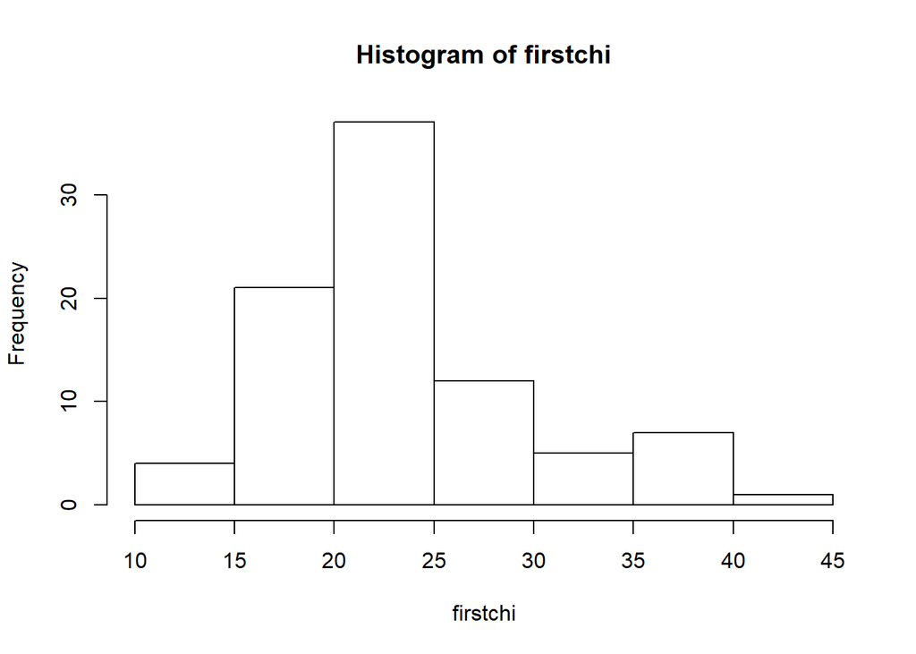

```r
data(firstchi)
hist(firstchi)
```

Predictions: Median:26 Mean:27.5 Standard deviation:5

```r
median(firstchi)
```

```
## [1] 23
```

```r
mean(firstchi)
```

```
## [1] 23.97701
```

```r
sd(firstchi)
```

```
## [1] 6.254258
```

3. Predict for math:

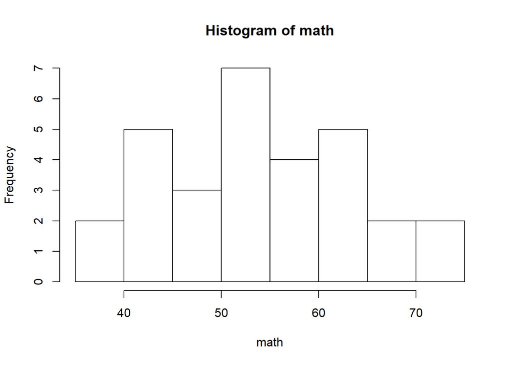

```r
data(math)
hist(math)
```

Predictions: Median:55 Mean:55 Standard deviation:10

```r
median(math)
```

```
## [1] 54
```

```r
mean(math)
```

```
## [1] 54.9
```

```r
sd(math)
```

```
## [1] 9.746264
```

Exercise 1.6 Number of O-ring failures for the first 23 flights of the US space shuttle Challenger : 0,1,0,NA,0,0,0,0,0,1,1,1,0,0,3,0,0,0,0,0,2,0,1

```r
flights=c(0,1,0,NA,0,0,0,0,0,1,1,1,0,0,3,0,0,0,0,0,2,0,1)
fl=table(flights)
print(fl)
```

```
## flights
##  0  1  2  3
## 15  5  1  1
```

```r
mean(fl[!is.na(fl)])
```

```
## [1] 5.5
```

Exercise 1.7

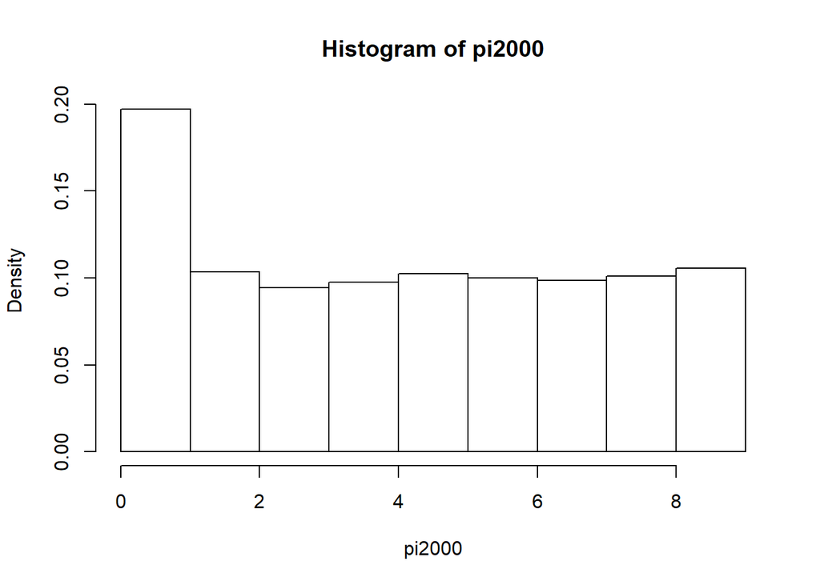

```r
hist(pi2000,probability = TRUE)
```

```r
prop=table(pi2000)/length(pi2000)
print(prop)
```

```
## pi2000
##      0      1      2      3      4      5      6      7      8      9
## 0.0905 0.1065 0.1035 0.0945 0.0975 0.1025 0.1000 0.0985 0.1010 0.1055
```

```r
print(prop[2])
```

```
##      1
## 0.1065
```

```r
print(prop[3])
```

```
##      2
## 0.1035
```

```r
print(prop[4])
```

```
##      3
## 0.0945
```

We can estimate the proportions for all digits The proportion for 1’s,2’s and 3’s are: 1)0.1065 2)0.1035 3)0.0945

Exercise 1.8 Fit a density to pi2000

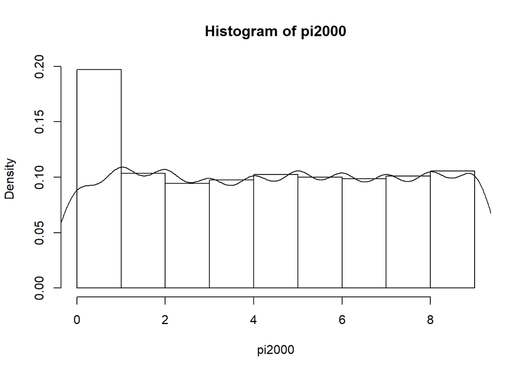

```r
data(pi2000)
#attach(prop)
hist(pi2000,probability=TRUE)
lines(density(pi2000,bw=0.45))
```